# Parse peptides and estimate proportion nascent

Tom Smith code – applied to Aris data

Cambridge Centre for Proteomics

27 February, 2024

Abstract

Here, we parse the peptide-level output from Proteome Discoverer and extract the proportion nascent at the peptide level. We then aggregate over peptides from the same peptide to obtain the protein-level proportion.

```r
#### Load packages ####
suppressMessages(library(camprotR))
suppressMessages(library(ggplot2))
suppressMessages(library(tidyverse))
suppressMessages(library(MSnbase))
#library(ggbeeswarm)
#library(GO.db)
suppressMessages(library(gplots))
suppressMessages(library(here))

# Standardise plotting aesthetics
source(here('R/plotting.R'))

select <- dplyr::select
```

Make the cRAP list for filtering

```r
# Load the cRAP FASTA used for the PD search
crap.fasta <- Biostrings::fasta.index(
  here('raw/cRAP_FullIdentifiers.fasta'),
  seqtype = "AA"
)

# Extract the non cRAP UniProt accessions associated with each cRAP protein
crap.accessions <- crap.fasta %>%
  pull(desc) %>%
  stringr::str_extract_all("(?<=\\|).*?(?=\\|)") %>%
  unlist() %>%
  .[!. %in% "000000"] # remove invalid UniProt accessions
```

We have multiple MS runs, so peptide sequence -> master protein assignments will not be consistent between runs. Below, we generate a consensus sequence to master protein assignment using an approximate parsimony approach

```
With original assignments, 9331 master proteins. With update, 8394 master proteins

Storing counts in `nn`, as `n` already present in inputStoring counts in `nn`, as `n` already present in input
```

```
.
Different ID(s)      Same ID(s)
          18863          449294
.
Different ID(s)      Same ID(s)
              4              96
```

|  | Updated:Multiple | Updated:Single |
| --- | --- | --- |
| Original:Multiple | 1838 | 13202 |
| Original:Single | 2732 | 450385 |

|  | Updated:Multiple | Updated:Single |
| --- | --- | --- |
| Original:Multiple | 0.39 | 2.82 |
| Original:Single | 0.58 | 96.20 |

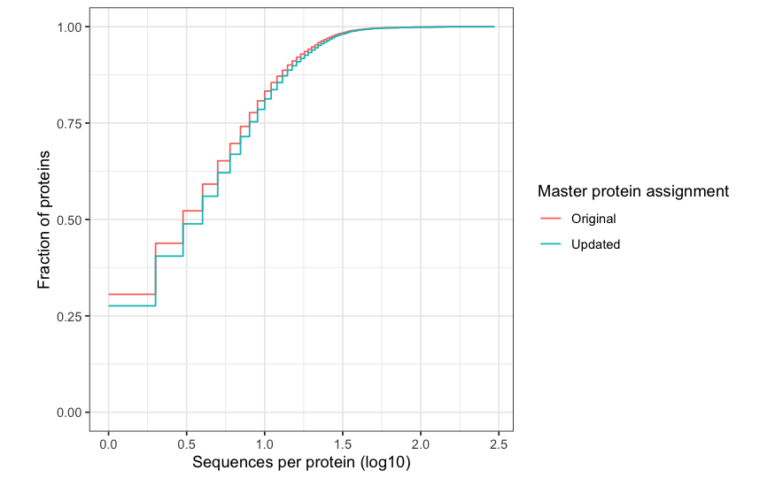

```r
peptide_infiles <- Sys.glob(here('raw/*_PeptideGroups.txt'))


new_seq_to_master <- get_parsimony_pep2prot(peptide_infiles, seq_col='Sequence')
```

To get the information about which intensities are from PSMs relative to a spectrum matched peptide, we need to interrogate the PSM level data using `camprotR::silac_psm_seq_int`.

Below, we read in the results from the individual PD runs for each SILAC experiment, filter out cRAP proteins and peptides with redundant ‘Quan.Info’ etc and merge with the ‘sequenced’ information from the PSM-level files.

```r
abundance_data <- vector('list', length=length(peptide_infiles))
names(abundance_data) <- peptide_infiles


for(infile in peptide_infiles){

  .data <- suppressMessages(parse_features(read.delim(infile),
                          silac = TRUE,
                          crap_proteins = crap.accessions,
                          unique_master=FALSE))

  infile_name <- gsub('_PeptideGroups.txt$', '', basename(infile))

  # merge in the 'sequenced' information from the PSM-level data
  psm_infile_name <- gsub('_PeptideGroups.txt$', '_PSMs.txt', infile)

  # modifications are written differently by PD in PSM and peptide-level files,
  # Here we update the modification column before the merge
  .data <- .data %>%
    mutate(Modifications=remove_silac_modifications(Modifications, level='peptide')) %>%
    rowwise()

  sample_n <- strsplit(infile, split='_')[[1]][2]

  # heavy and light column names vary from sample to sample, so we grep them out
  abundance_light_col <- colnames(.data)[grepl('Abundance.F[[:digit:]]{1,2}.Light.Sample', colnames(.data))]
  abundance_heavy_col <- colnames(.data)[grepl('Abundance.F[[:digit:]]{1,2}.Heavy.Sample', colnames(.data))]

  # Filter to remove:
  # 1. No quantification
  # 2. Contaminants (according to PD, we have already removed most contaminants above with parse_features())

  # Add columns for heavy and light
  # Select required columns
  # Make unique rownames from sequence and modifications
  .data <- .data %>%
    filter(Quan.Info=='',
           Contaminant=='False',
           !grepl('cRAP', Protein.Accessions),
           !grepl('keratin', ignore.case=TRUE, Master.Protein.Descriptions)) %>%
    mutate('heavy'=!!sym(abundance_heavy_col),
           'light'=!!sym(abundance_light_col),
           'row'=paste0(Sequence, '_:_', Modifications)) %>%
    dplyr::select(heavy, light,
                  Master.Protein.Accessions,
                  Master.Protein.Descriptions,
                  row) %>%
    tibble::column_to_rownames('row')

  abundance_data[[infile]] <- .data
}
```

Below, we combine all the data sets and whilst doing so, add `type`, `replicate` columns describing the MS run

```r
# File contains sample information
fileNames <- read.csv(here("raw/sampleInfo.csv"))

abundance_data_complete <- abundance_data %>% names() %>% lapply(function(x){

  filename_split <- strsplit(basename(x), split='_')[[1]]
  sample_No <- filename_split[2]
  subset <- fileNames %>% filter(number == sample_No)

  cell_line <- subset$cell_line
  timepoint <- subset$time
  treatment <- subset$trt
  rep <- subset$rep

  pep_data <- abundance_data[[x]] %>%
    tibble::rownames_to_column('Sequence_modifications') %>%
    mutate('cell_line'=cell_line, 'replicate'=rep, 'time_point'=timepoint, 'condition'=treatment) %>%
    separate(Sequence_modifications, into=c('Sequence', 'Modifications'),
             sep='_:_')
}) %>% do.call(what='rbind') %>%
  merge(new_seq_to_master, by='Sequence')

abundance_data_complete <- abundance_data_complete %>%
  filter(!grepl(';', Updated.Master.Protein.Accessions))

table(abundance_data_complete$condition)
```

```
   GC7  untrt
163477 167672
```

```r
print(dim(abundance_data_complete))
```

```
[1] 331149     11
```

```r
head(abundance_data_complete)
```

|  | Sequence | Modifications | heavy | light | Master.Protein.Accessions | Master.Protein.Descriptions | cell_line | replicate | time_point | condition | Updated.Master.Protein.Accessions |
| --- | --- | --- | --- | --- | --- | --- | --- | --- | --- | --- | --- |
| 1 | AAAAAAAAAAAAAAAGAGAGAK |  | 2216785 | 9585197 | P55011 | Solute carrier family 12 member 2 OS=Homo sapiens OX=9606 GN=SLC12A2 PE=1 SV=1 | A549 | 2 | 3 | GC7 | P55011 |
| 2 | AAAAAAAAAAAAAAAGAGAGAK |  | 1163914 | 5660800 | P55011 | Solute carrier family 12 member 2 OS=Homo sapiens OX=9606 GN=SLC12A2 PE=1 SV=1 | A549 | 2 | 3 | untrt | P55011 |
| 3 | AAAAAAAAAAAAAAAGAGAGAK |  | 49637192 | 13466910 | P55011 | Solute carrier family 12 member 2 OS=Homo sapiens OX=9606 GN=SLC12A2 PE=1 SV=1 | A549 | 3 | 24 | untrt | P55011 |
| 4 | AAAAAAAAAAAAAAAGAGAGAK |  | 4014832 | 8310108 | P55011 | Solute carrier family 12 member 2 OS=Homo sapiens OX=9606 GN=SLC12A2 PE=1 SV=1 | A549 | 1 | 6 | untrt | P55011 |
| 5 | AAAAAAAAAAAAAAAGAGAGAK |  | 9972980 | 2624108 | P55011 | Solute carrier family 12 member 2 OS=Homo sapiens OX=9606 GN=SLC12A2 PE=1 SV=1 | A549 | 2 | 24 | GC7 | P55011 |
| 6 | AAAAAAAAAAAAAAAGAGAGAK |  | 7752759 | 26374444 | P55011 | Solute carrier family 12 member 2 OS=Homo sapiens OX=9606 GN=SLC12A2 PE=1 SV=1 | A549 | 3 | 3 | untrt | P55011 |

Summarise the number of proteins per cell line

```r
# how many unique proteins
sprintf("There are %s proteins identified (not necessarily both isotypes sequenced)", (length(unique(abundance_data_complete$Master.Protein.Accessions))))
```

```
[1] "There are 7619 proteins identified (not necessarily both isotypes sequenced)"
```

```r
abundance_data_complete %>%
  filter((is.finite(heavy) & is.finite(light))) %>%
  group_by(condition) %>%
  tally()
```

| condition | n |
| --- | --- |
| GC7 | 113049 |
| untrt | 121108 |

```r
NA
NA
NA
```

~5-20,000 peptides per sample

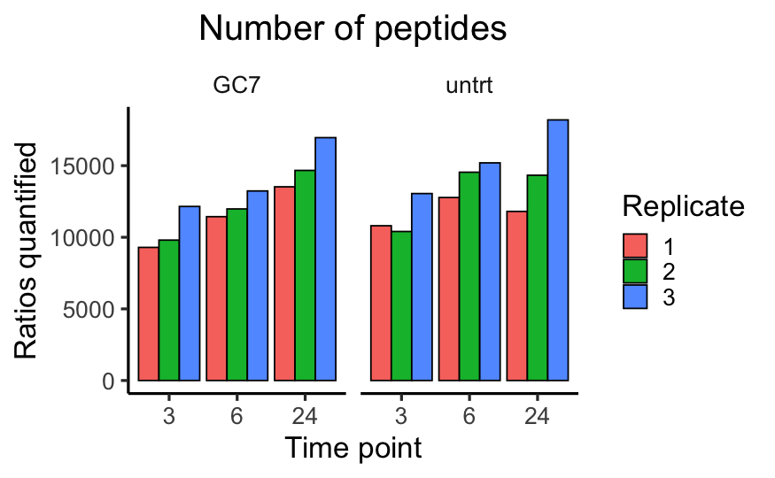

```r
toPlot <- abundance_data_complete %>%
  filter((is.finite(heavy) & is.finite(light))) %>%
  group_by(condition, replicate, time_point) %>%
  tally()


ggplot(toPlot, aes(x=as.factor(time_point), y=n, group=replicate, fill=as.factor(replicate))) +
  geom_bar(stat="identity", position=position_dodge(), color="black") +
  facet_grid(.~condition) +
  xlab("Time point") +
  ylab('Ratios quantified') +
  ggtitle("Number of peptides") +
  guides(fill=guide_legend(title="Replicate"))
```

```r
#dev.off()
```

calculate the proportions and summarise the spectrum matched status

```r
spectrum_match_levels <- c('Mixed spectrum matched', 'Some Both spectrum matched',
                           'Some Heavy spectrum matched', 'Some Light spectrum matched',
                           'Both spectrum matched', 'Heavy spectrum matched', 'Light spectrum matched')


proportion <- abundance_data_complete %>% #head() %>%
  filter((is.finite(heavy) | is.finite(light))) %>%
  mutate(heavy=log2(heavy), light=log2(light)) %>%
  get_ratio(heavy, light, bind = TRUE) %>%
  mutate(proportion=2^heavy/(2^light+2^heavy))



print(head(proportion))
```

|  | Sequence | Modifications | heavy | light | Master.Protein.Accessions | Master.Protein.Descriptions | cell_line | replicate | time_point | condition | Updated.Master.Protein.Accessions | ratio | missing | proportion |
| --- | --- | --- | --- | --- | --- | --- | --- | --- | --- | --- | --- | --- | --- | --- |
| 1 | AAAAAAAAAAAAAAAGAGAGAK |  | 21.08004 | 23.19238 | P55011 | Solute carrier family 12 member 2 OS=Homo sapiens OX=9606 GN=SLC12A2 PE=1 SV=1 | A549 | 2 | 3 | GC7 | P55011 | -2.112339 | Neither missing | 0.1878316 |
| 2 | AAAAAAAAAAAAAAAGAGAGAK |  | 20.15055 | 22.43257 | P55011 | Solute carrier family 12 member 2 OS=Homo sapiens OX=9606 GN=SLC12A2 PE=1 SV=1 | A549 | 2 | 3 | untrt | P55011 | -2.282022 | Neither missing | 0.1705440 |
| 3 | AAAAAAAAAAAAAAAGAGAGAK |  | 25.56492 | 23.68292 | P55011 | Solute carrier family 12 member 2 OS=Homo sapiens OX=9606 GN=SLC12A2 PE=1 SV=1 | A549 | 3 | 24 | untrt | P55011 | 1.882003 | Neither missing | 0.7865922 |
| 4 | AAAAAAAAAAAAAAAGAGAGAK |  | 21.93691 | 22.98644 | P55011 | Solute carrier family 12 member 2 OS=Homo sapiens OX=9606 GN=SLC12A2 PE=1 SV=1 | A549 | 1 | 6 | untrt | P55011 | -1.049528 | Neither missing | 0.3257486 |
| 5 | AAAAAAAAAAAAAAAGAGAGAK |  | 23.24959 | 21.32340 | P55011 | Solute carrier family 12 member 2 OS=Homo sapiens OX=9606 GN=SLC12A2 PE=1 SV=1 | A549 | 2 | 24 | GC7 | P55011 | 1.926197 | Neither missing | 0.7916893 |
| 6 | AAAAAAAAAAAAAAAGAGAGAK |  | 22.88628 | 24.65264 | P55011 | Solute carrier family 12 member 2 OS=Homo sapiens OX=9606 GN=SLC12A2 PE=1 SV=1 | A549 | 3 | 3 | untrt | P55011 | -1.766359 | Neither missing | 0.2271724 |

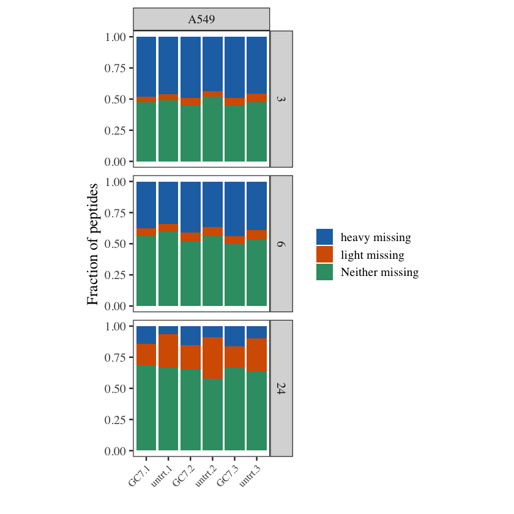

```r
p <- proportion %>%
  select(cell_line, time_point, missing, condition, replicate, Updated.Master.Protein.Accessions) %>%
  distinct() %>%
  group_by(cell_line, time_point, missing, condition, replicate) %>%
  tally() %>%
  ggplot(aes(interaction(condition, replicate), n, fill=missing)) +
  theme_camprot( base_size=15) +
  facet_grid(time_point~ cell_line, scales='free') +
  scale_fill_manual(values=get_cat_palette(3), name='') +
  xlab('') +
  ylab('Fraction of peptides') +
  theme(axis.text.x=element_text(size=10, angle=45, vjust=1, hjust=1))

print(p + geom_bar(stat='summary', position='fill'))
```

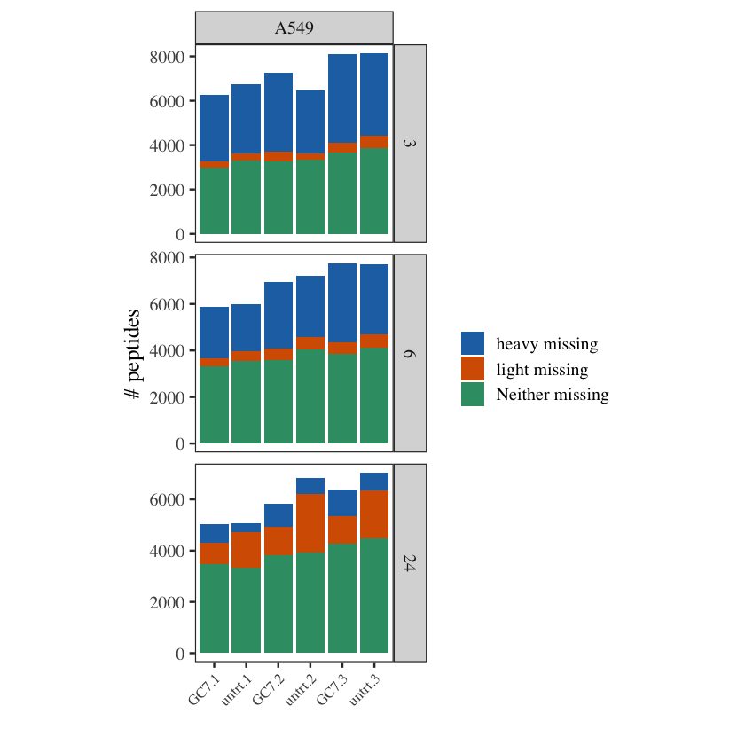

```r
print(p + geom_bar(stat='summary', position='stack') +
    ylab('# peptides'))
```

```r
NA
NA
```

Inspecting the ratios at the peptide level.

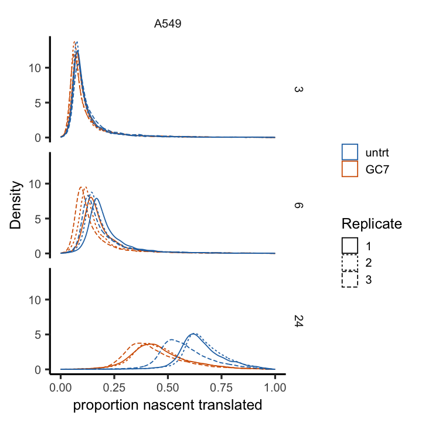

```r
proportion$condition <- factor(proportion$condition, levels= c("untrt", "GC7"))

p <- proportion %>%
  ggplot(aes(proportion, colour=condition, linetype=factor(replicate), group=(paste(condition, replicate)))) +
  geom_density() +
  theme(text=element_text(size=15)) +
  facet_grid(time_point~cell_line) +
  scale_colour_manual(values=get_cat_palette(2), name='') +
  scale_linetype_discrete(name='Replicate') +
  ylab('Density') +
  xlab('proportion nascent translated')

print(p)
```

Checking overall intensity is approximately the same for each experiment. Very consistent between the replicates.

```r
proportion %>%
  group_by(condition, time_point) %>%
  summarise('median'=median(heavy, na.rm=TRUE))
```

| condition | time_point | median |
| --- | --- | --- |
| untrt | 3 | 22.12528 |
| untrt | 6 | 22.86971 |
| untrt | 24 | 24.32475 |
| GC7 | 3 | 22.42147 |
| GC7 | 6 | 22.60255 |
| GC7 | 24 | 23.94549 |

```r
p <- proportion %>%
  #filter(!glyco_GO_RBP %in% c('GO:LC_RBGP', 'GO:HC_RBGP')) %>%
  ggplot(aes(light, linetype=condition, colour=factor(time_point), group=(paste(time_point, replicate, condition)))) +
  #xlim(-1,3) +
  xlab('Intensity (light isotope)') +
  geom_density() +
  theme_camprot(base_size=15) +
  #scale_colour_manual(values=get_cat_palette(6), name='') +
  scale_linetype_discrete(name='Condition') +
  scale_colour_manual(values=get_cat_palette(3), name='Time (h)')
  ylab('Density')
```

```
$y
[1] "Density"

attr(,"class")
[1] "labels"
```

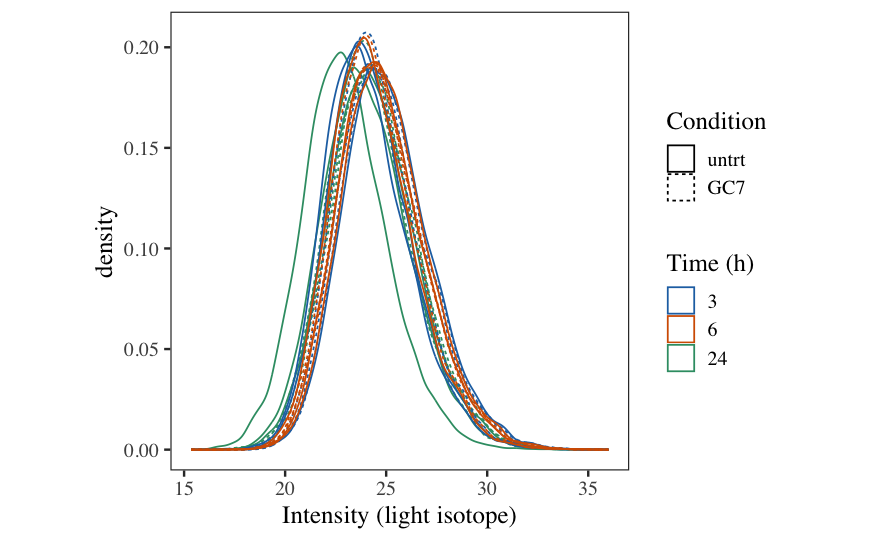

```r
print(p)
```

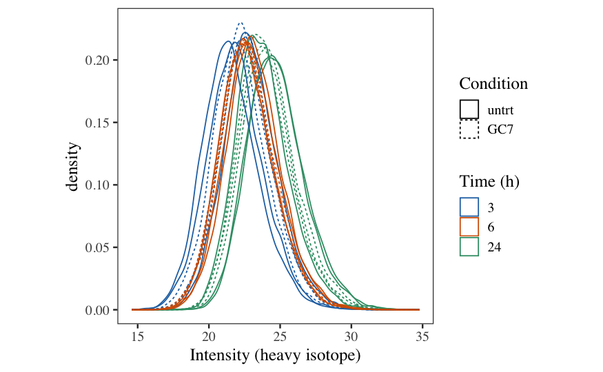

```r
print(p + aes(heavy) + xlab('Intensity (heavy isotope)'))
```

```r
NA
NA
```

Below, we make MSnSets from the peptide-level proportions.

```r
makeMsnSet <- function(ratios){

  flt_ratios <- ratios %>%
    filter(is.finite(ratio))

  exprs_data <- flt_ratios %>%
    mutate(sample=paste(time_point, condition, gsub(' ', '.', replicate), sep='_')) %>%
    dplyr::select(Updated.Master.Protein.Accessions, Master.Protein.Descriptions, Sequence, Modifications,
                  sample, proportion) %>%
    spread(key=sample, value=proportion)

  feature_data <- flt_ratios %>%
    dplyr::select(Updated.Master.Protein.Accessions, Master.Protein.Descriptions, Sequence, Modifications) %>%
    distinct()

  # make sure the exprs and fData are in the same order
  feature_data <- feature_data[
    match(interaction(exprs_data[c('Sequence', 'Modifications')]),
          interaction(feature_data[c('Sequence', 'Modifications')])),]

  exprs_data <- exprs_data %>%
    dplyr::select(-c(Updated.Master.Protein.Accessions, Master.Protein.Descriptions, Sequence, Modifications)) %>%
    as.matrix()

  rownames(exprs_data) <- 1:nrow(exprs_data)
  rownames(feature_data) <- 1:nrow(feature_data)

  peptide_abundance <- MSnSet(exprs=exprs_data, fData=feature_data)

  pData(peptide_abundance)$sample <- colnames(peptide_abundance)
  pData(peptide_abundance) <- pData(peptide_abundance) %>% separate(sample, into=c('type', 'condition', 'replicate'), sep='_')

  peptide_abundance
}

proportions <- makeMsnSet(proportion)
```

`proportions` is an MSnSet.

Next we want to aggregate the proportions to get protein level proportions. First though, we need to decide how many peptides per protein will demand. More = more accurate quantification but fewer proteins quantified. Two is typically used, despite being very low.

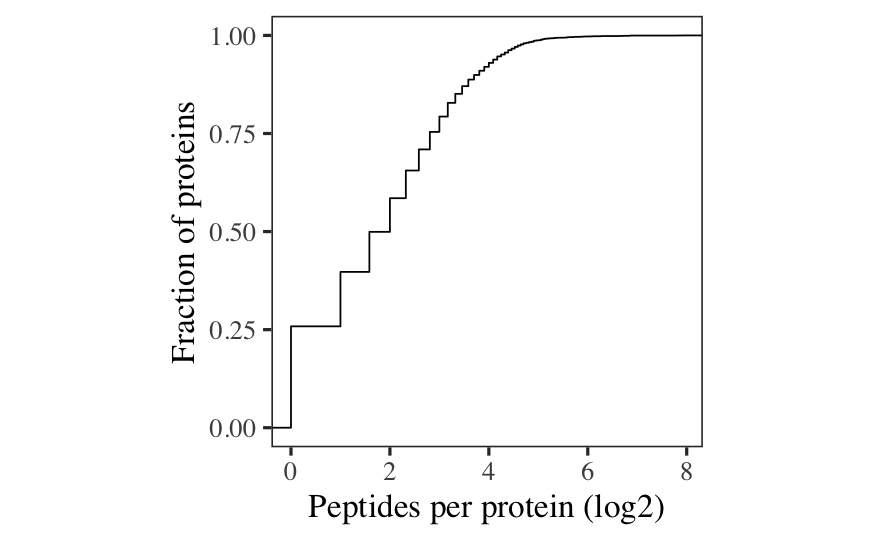

```r
proportions %>%
  fData() %>%
  group_by(Updated.Master.Protein.Accessions) %>%
  tally() %>%
  ggplot(aes(log2(n))) +
  stat_ecdf() +
  theme_camprot() +
  xlab('Peptides per protein (log2)') +
  ylab('Fraction of proteins')
```

```r
NA
```

So, roughly half the proteins only have 3 peptides in total across all samples. Let’s look at this in more detail and see how filtering by peptides per protein will affect the final number of proteins quantified.

```r
CheckFilteringOptions <- function(peptide_abundance,
                                  min_peptides_range=1:4){
  rows <- NULL
    for(min_peptides in min_peptides_range){
      .data <- restrict_features_per_protein(peptide_abundance, min_features=min_peptides,
                                             master_protein_col='Updated.Master.Protein.Accessions', plot=FALSE)
      fData(.data)$min_peptides <- min_peptides

      retain_columns <- colnames(fData(.data))[!grepl('^MBR_', colnames(fData(.data)))]
      rows[[min_peptides]] <- fData(.data)[,retain_columns]

      }

  peptide_filtering_options <- data.frame(do.call('rbind', rows))

  return(peptide_filtering_options)
}

peptide_filtering_options <- CheckFilteringOptions(proportions)
```

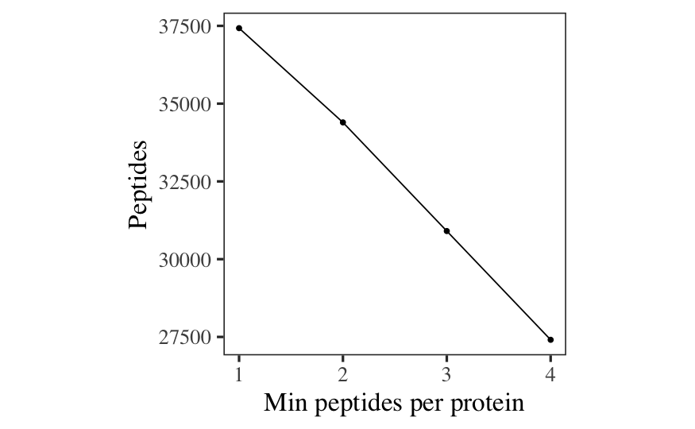

```r
peptide_filtering_options_peptides <- peptide_filtering_options %>%
  select(Sequence, min_peptides) %>%
  distinct() %>%
  group_by(min_peptides) %>%
  tally()

peptide_filtering_options_proteins <- peptide_filtering_options %>%
  select(Updated.Master.Protein.Accessions, min_peptides) %>%
  distinct() %>%
  group_by(min_peptides) %>%
  tally()

p <- peptide_filtering_options_peptides %>%
  ggplot(aes(min_peptides, n)) +
  geom_line() +
  geom_point() +
  theme_camprot() +
  ylab('Peptides') +
  scale_colour_manual(values=get_cat_palette(2), name='') +
  xlab('Min peptides per protein')

print(p)
```

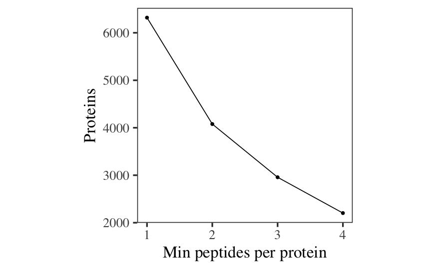

```r
print(p %+% peptide_filtering_options_proteins + ylab('Proteins'))
```

OK, so if we use minimum of 2 peptides per protein, we have ~ 4000 proteins.

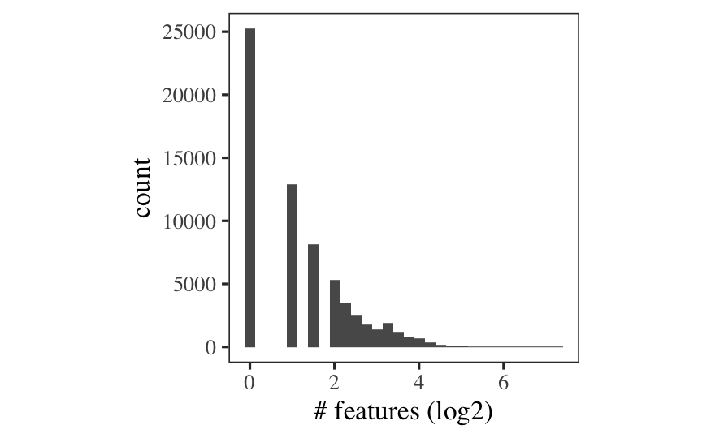

```r
agg2protein <- function(pep_proportions){

  pep_proportions <- pep_proportions %>%
    restrict_features_per_protein(min_features=2, master_protein_col='Updated.Master.Protein.Accessions')


  prot <-  combineFeatures(
    pep_proportions,
    groupBy = fData(pep_proportions)$Updated.Master.Protein.Accessions,
    method = "median",
    na.rm = TRUE,
  )

  # we'll drop all the other feature data since these are peptide-level features
  fData(prot) <- fData(prot)[,c( 'Updated.Master.Protein.Accessions', 'Master.Protein.Descriptions')]

  prot
}


prot_proportions <- proportions %>% agg2protein()
```

```r
plotMissing <- function(obj, missing_col=get_cat_palette(3), present_col='black', verbose=TRUE, ...){
  tmp_obj <- obj
  exprs(tmp_obj)[!is.na(exprs(tmp_obj))] <- 1
  exprs(tmp_obj)[is.na(exprs(tmp_obj))] <- 0

  missing <- exprs(tmp_obj)

  missing <- missing[rowSums(missing==0)>0,,drop=FALSE] # identify features with missing values

  if(verbose){
    cat(sprintf("Out of %s total features, %s (%s%%) have missing values\n",
                length(rownames(exprs(tmp_obj))), length(rownames(missing)),
                round(100*length(rownames(missing))/length(rownames(exprs(tmp_obj))),3)))
    if(nrow(missing)>1){
      print(table(rowSums(missing==0)))
    }
  }

  if(nrow(missing)>1){
    missing_twice <- missing[rowSums(missing==0)>1,]

    if(verbose){
      cat(sprintf("And %s features have more than one missing value\n", length(rownames(missing_twice))))
    }

    colnames(missing) <- pData(tmp_obj)$Sample_name

    heatmap.2(missing, col = c(missing_col, present_col),
              scale = "none", dendrogram = "none",
              trace = "none", keysize = 0.5, key = FALSE,Colv = F, labRow=F,
              ...)
  }
}


table(is.na(prot_proportions))
```

```
FALSE  TRUE
40984 32420
```

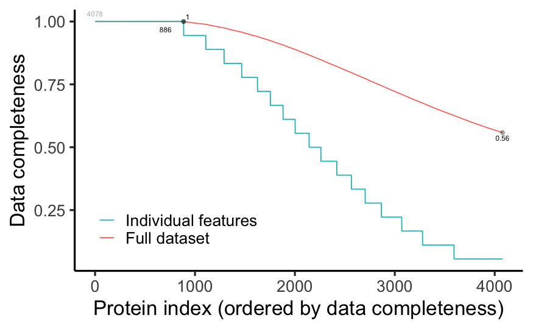

```r
plotNA(prot_proportions, pNA=0)
```

```
Out of 4078 total features, 3192 (78.274%) have missing values

  1   2   3   4   5   6   7   8   9  10  11  12  13  14  15  16  17
222 183 176 158 129 127 121 140 118 159 146 138 162 204 208 315 486
And 2970 features have more than one missing value
```

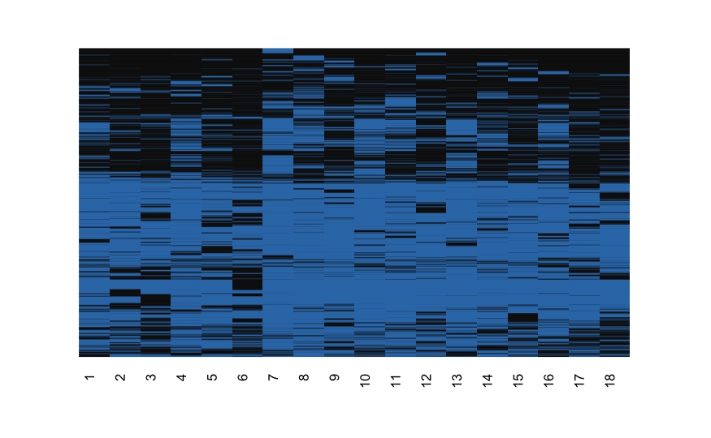

```r
prot_proportions %>% plotMissing()
```

Save out the objects we will need in downstream notebooks.

```r
saveRDS(prot_proportions, here('results/prot_proportion.rds'))
saveRDS(proportions, here('results/pep_proportion.rds'))
saveRDS(proportion, here('results/pep_proportion_long.rds'))
```